# Principios de Estadística Aplicada con R

Teorema de Límite Central

Gabriel Carrasco Escobar

Universidad Peruana Cayetano Heredia

Jorge Ruiz Cabrejos

Universidad Peruana Cayetano Heredia

08 de febrero del 2018

Rutinas y comandos complementarios del curso *Principios de Estadística Aplicada con R (PEAR)*

*Cualquier problema con este código, porfavor contactar a gabriel.carrasco@upch.pe*

Los paquetes que se utilizaran son:

```r
library(dplyr)
library(rafalib)
```

Los ejercicios a continuación utilizan la base de datos `Winzell2004_covar_v2.csv`, a la que colocaremos de nombre `dat`.

```r
dat <- read.csv("C:/Usuario/Estudiante/Escritorio/Estadistica/Winzell2004_covar_v2.csv")
```

## Introducción al TLC

El teorema de limite central (TLC) plantea que cuando las observaciones son (1) muestras independientes (2) obtenidas aleatoriamente (3) de una población con distribución normal, se cumple lo siguiente:

- La distribución de los valores de las medias muestrales seguirán una distribución normal.
- El promedio de la distribución muestral será igual al promedio real de la población.
- La varianza de la distribución muestral será igual a la varianza de la población dividida entre el tamaño de la muestra
- La desviación estándar de la distribución muestral está referida como “error estándar” del estadístico

## Muestreo en R

Para demostrar el TLC, empezaremos utilizando `mean` para hallar la media de la variable `Bodyweight`. Añadimos la opcion `na.rm=T` para que nuestro resultado no sea `NA`

```r
mean(dat$Bodyweight,na.rm=T)
```

```
## [1] 28.84704
```

La base de datos `Winzell2004_covar_v2.csv` tiene 846 observaciones, por lo que el resultado anterior es la media de estas 846 observaciones.

Ahora, con la función `sample` escogemos una muestra aleatoria de estas 846 observaciones.

Para este ejemplo, utilizaremos una muestra de 100 observaciones de la variabñle `Bodyweight`, la cual definiremos en el objeto `N`. Los datos escogidos aleatoriamente por R lo almacenaremos en `X`.

```r
N <- 100
X <- sample(dat$Bodyweight,N)
```

Ahora, sacamos la media de `X`. ¿La respuesta es similar?

```r
mean(X,na.rm=T)
```

[output not shown]

Para comprobar que la función `sample` esta tomando los valores de la variable `Bodyweight` de forma aleatoria, a continuación lo probamos tres veces más a manera de ejemplo y con distintos tamaños de muestra:

#### Prueba 1

```r
N <- 50
X <- sample(dat$Bodyweight,N)
mean(X,na.rm=T)
```

```
## [1] 28.6966
```

#### Prueba 2

```r
N <- 100
X <- sample(dat$Bodyweight,N)
mean(X,na.rm=T)
```

```
## [1] 28.6814
```

#### Prueba 3

```r
N <- 200
X <- sample(dat$Bodyweight,N)
mean(X,na.rm=T)
```

```
## [1] 29.32935
```

## Loops

Un loop nos permite realizar una serie de acciones o comandos de forma repititiva.

Para continuar con la demostración del TLC, utilizaremos un loop para realizar el ejercicio anterior 10 mil veces. Para el ejemplo, primero definimos el número de repeticiones en `rep`. A continuación, creamos un vector numérico al que nombraremos `tlc` y definimos el número de muestras aleatorias que el loop escogera cada vez que se repita (para este caso 100).

```r
rep <- 10000
tlc <- vector("numeric",rep)
N <- 100
```

Con estos tres objetos creados, procedemos a incluirlos dentro del loop

```r
for (i in 1:rep) {
  sample <- sample(dat$Bodyweight,N)
  tlc[i] <- mean(sample, na.rm=T)
}
```

El resultado es un vector llamado `tlc` que contiene 10 mil medias escogidas aleatoriamente de la variable `Bodyweight`. Para visualizarlo lo graficamos con `hist`.

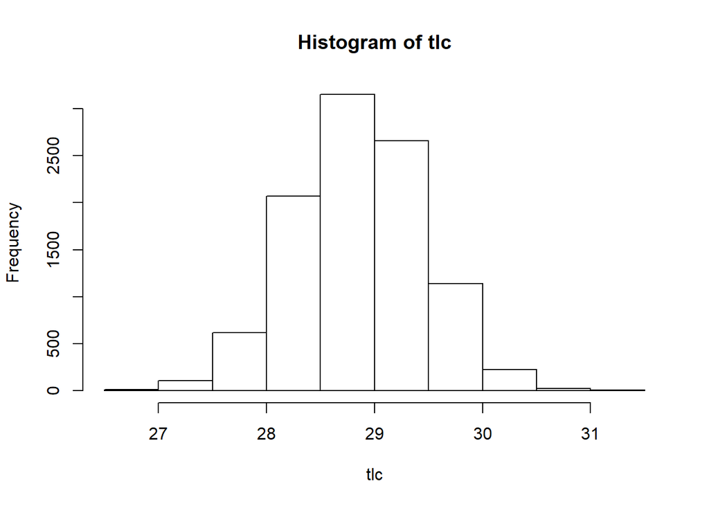

```r
hist(tlc)
```

Complementamos el análisis colocando una linea con la media de `Bodyweight` y `tlc`.

La opción `lwd` nos permite aumentar el grosor de la línea.

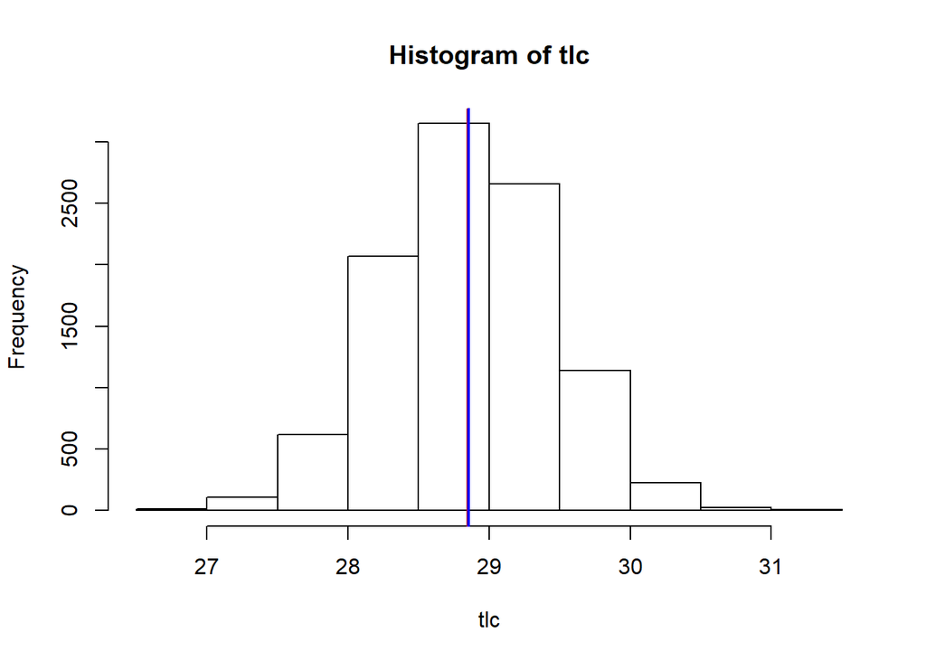

```r
hist(tlc)
abline(v=mean(dat$Bodyweight, na.rm=T), col="red", lwd=2)
abline(v=mean(tlc), col="blue", lwd=2)
```

Utilizando la función `summary` en el objeto `tlc` obtenemos más información acerca de su contenido.

```r
summary(tlc)
```

```
##    Min. 1st Qu.  Median    Mean 3rd Qu.    Max.
##   26.72   28.45   28.86   28.85   29.26   31.28
```